# Instability as a Data Quality Issue in Wikipedia

- Show All Code
- Hide All Code
- View Source

*Evidence from Diversity-Related Topics in English Wikipedia*

Author

Anju Yamada

Published

01.01.2026

Modified

13.04.2026

Keywords

Wikipedia, data quality, instability, diversity, edit conflict, burstiness

## 1 Introduction

Wikipedia is one of the most widely used knowledge infrastructures in the world. However, its content is not fixed. It is continuously updated, revised, and contested by editors. This dynamic character makes Wikipedia not only a source of information, but also a data system shaped by social processes.

This study examines whether diversity-related Wikipedia pages are associated with greater instability, and whether such instability can be understood as a data quality issue. Our main concern is not simply whether some pages attract more attention, but whether external attention and internal contestation make page content less stable and therefore less reliable as data.

We focus on English Wikipedia and examine whether diversity-related pages differ from other pages in terms of revert-related instability, bursty editing dynamics, and the concentration of edits across time.

### 1.1 Research Questions

- Are diversity-related Wikipedia pages more unstable than other pages?
- Does instability appear primarily as revert-related conflict or as bursty temporal concentration?
- Can mitigation strategies improve data reliability?

### 1.2 Hypotheses

- **H1**: Diversity-related pages have higher revert-related instability.
- **H2**: Diversity-related pages show stronger editing bursts.
- **H3**: Diversity-related pages are more likely to experience burst days.

## 2 Data and Research Design

We use Wikimedia data for English Wikipedia, combining page-level metadata, daily pageviews, and edit logs. Diversity-related pages are defined conservatively using the label `Culture.Biography.Women`. We also identify biography pages using `Culture.Biography.Biography*`.

Our analysis distinguishes between two kinds of instability:

1. **Structural instability** at the page level  
   This captures whether editing activity is concentrated into a small number of days for a page overall.
2. **Temporal instability** at the day level  
   This captures whether a specific page-day is unusually intense relative to that page’s normal editing pattern.

We interpret both as potential data quality issues, especially in relation to consistency and reliability.

## 3 Data Preparation

```r
options(repos = c(CRAN = "https://cran.r-project.org"))
set.seed(2026)

library(jsonlite)
library(dplyr)
library(purrr)
library(stringr)
library(lubridate)
library(tidyr)
library(ggplot2)
library(readr)
library(knitr)
library(kableExtra)
```

```r
# -------------------------
# Output folders
# -------------------------
output_dir <- "output"
fig_dir <- file.path(output_dir, "figures")
table_dir <- file.path(output_dir, "tables")

if (!dir.exists(output_dir)) dir.create(output_dir)
if (!dir.exists(fig_dir)) dir.create(fig_dir, recursive = TRUE)
if (!dir.exists(table_dir)) dir.create(table_dir, recursive = TRUE)

# -------------------------
# Quarto/knitr figure path
# -------------------------
knitr::opts_chunk$set(
  fig.path = "output/figures/"
)

# -------------------------
# Helper functions for saving
# -------------------------
save_table_csv <- function(x, filename) {
  readr::write_csv(x, file.path(table_dir, filename))
}

save_plot_png <- function(plot_obj, filename, width = 8, height = 5, dpi = 300) {
  ggplot2::ggsave(
    filename = file.path(fig_dir, filename),
    plot = plot_obj,
    width = width,
    height = height,
    dpi = dpi
  )
}
```

```r
#| label: 01_import_data
#| warning: false
#| message: false

n_read <- 50000

pageviews_path <- file.path("Data", "page_views.json.gz")
pageinfo_path  <- file.path("Data", "page_info.json.gz")
enwiki_path    <- file.path("Data", "enwiki.json.gz")

print(pageviews_path)
```

```
[1] "Data/page_views.json.gz"
```

```r
print(pageinfo_path)
```

```
[1] "Data/page_info.json.gz"
```

```r
print(enwiki_path)
```

```
[1] "Data/enwiki.json.gz"
```

```r
stopifnot(file.exists(pageviews_path))
stopifnot(file.exists(pageinfo_path))
stopifnot(file.exists(enwiki_path))

con_pageviews <- textConnection(readLines(gzfile(pageviews_path), n = n_read))
pageviews_sample <- stream_in(con_pageviews, verbose = FALSE)
close(con_pageviews)

con_pageinfo <- textConnection(readLines(gzfile(pageinfo_path), n = n_read))
pageinfo_sample <- stream_in(con_pageinfo, verbose = FALSE)
close(con_pageinfo)

con_enwiki <- textConnection(readLines(gzfile(enwiki_path), n = n_read))
enwiki_sample <- stream_in(con_enwiki, verbose = FALSE)
close(con_enwiki)
```

```r
get_label_prob <- function(label_df, target_label) {
  match <- label_df %>% filter(label == target_label)
  if (nrow(match) == 0) return(0)
  match$probability[1]
}

has_any_tag <- function(tags, target_tags) {
  if (is.null(tags) || length(tags) == 0) return(FALSE)
  if (is.list(tags) && !is.character(tags)) {
    tags <- unlist(tags, use.names = FALSE)
  }
  if (length(tags) == 1 && is.na(tags)) return(FALSE)
  tags_chr <- as.character(tags)
  any(tags_chr %in% target_tags)
}

safe_sd <- function(x) {
  if (length(x) <= 1) return(NA_real_)
  sd(x, na.rm = TRUE)
}

safe_quantile <- function(x, p) {
  if (length(x) == 0 || all(is.na(x))) return(NA_real_)
  as.numeric(quantile(x, p, na.rm = TRUE, type = 7))
}
```

```r
#| label: 03_prepare_data

pv_en <- pageviews_sample %>%
  filter(wiki_db == "enwiki")

pi_en <- pageinfo_sample %>%
  filter(wiki_db == "enwiki") %>%
  mutate(
    women_prob = map_dbl(predicted_labels, ~ get_label_prob(.x, "Culture.Biography.Women")),
    bio_prob   = map_dbl(predicted_labels, ~ get_label_prob(.x, "Culture.Biography.Biography*")),
    women_topic = women_prob > 0.20,
    biography_topic = bio_prob > 0.50,
    diversity_topic = women_topic
  )

pi_en_small <- pi_en %>%
  select(
    page_id,
    page_title,
    qid,
    total_pageviews = pageviews,
    women_prob,
    bio_prob,
    women_topic,
    biography_topic,
    diversity_topic
  )

edits_en <- enwiki_sample %>%
  filter(!is_bot) %>%
  mutate(
    revision_time = ymd_hms(revision_timestamp, quiet = TRUE),
    edit_day = as.Date(revision_time),
    is_reverted = map_lgl(revision_tags, ~ has_any_tag(.x, c("mw-reverted"))),
    is_revert_action = map_lgl(revision_tags, ~ has_any_tag(.x, c("mw-undo", "mw-rollback", "mw-manual-revert")))
  ) %>%
  left_join(pi_en_small, by = "page_id") %>%
  filter(!is.na(diversity_topic), !is.na(edit_day))
```

```r
#| label: 04_daily_analysis

pv_date_col <- intersect(names(pv_en), c("date", "timestamp", "view_day", "day"))

pv_daily_en <- pv_en %>%
  mutate(
    view_day_raw = .data[[pv_date_col[1]]],
    view_day = as.Date(view_day_raw)
  ) %>%
  group_by(page_id, view_day) %>%
  summarise(
    pageviews_day = sum(pageviews, na.rm = TRUE),
    .groups = "drop"
  )

daily_edits <- edits_en %>%
  group_by(page_id, page_title, diversity_topic, biography_topic, edit_day) %>%
  summarise(
    edits_day = n(),
    editors_day = n_distinct(user_text),
    reverted_day = sum(is_reverted, na.rm = TRUE),
    revert_action_day = sum(is_revert_action, na.rm = TRUE),
    reverted_share_day = reverted_day / edits_day,
    revert_action_share_day = revert_action_day / edits_day,
    .groups = "drop"
  )

daily_analysis <- daily_edits %>%
  group_by(page_id) %>%
  mutate(
    active_days = n(),
    mean_edits_page = mean(edits_day, na.rm = TRUE),
    sd_edits_page = safe_sd(edits_day),
    p95_edits_page = safe_quantile(edits_day, 0.95),
    max_edits_page = max(edits_day, na.rm = TRUE),
    burst_day = case_when(
      active_days < 5 ~ FALSE,
      TRUE ~ edits_day > p95_edits_page
    ),
    burst_day_sd = case_when(
      is.na(sd_edits_page) ~ FALSE,
      TRUE ~ edits_day > (mean_edits_page + 2 * sd_edits_page)
    ),
    burst_intensity = edits_day / sum(edits_day, na.rm = TRUE)
  ) %>%
  ungroup() %>%
  left_join(
    pv_daily_en,
    by = c("page_id" = "page_id", "edit_day" = "view_day")
  )

page_instability <- daily_analysis %>%
  group_by(page_id, page_title, diversity_topic, biography_topic) %>%
  summarise(
    n_active_days = n(),
    n_edits = sum(edits_day, na.rm = TRUE),
    mean_edits_day = mean(edits_day, na.rm = TRUE),
    max_edits_day = max(edits_day, na.rm = TRUE),
    mean_editors_day = mean(editors_day, na.rm = TRUE),
    mean_reverted_share_day = mean(reverted_share_day, na.rm = TRUE),
    burst_day_rate = mean(burst_day, na.rm = TRUE),
    edit_burst = max(edits_day, na.rm = TRUE) / sum(edits_day, na.rm = TRUE),
    mean_pageviews_day = mean(pageviews_day, na.rm = TRUE),
    .groups = "drop"
  )
```

## 4 Structural Instability at the Page Level

We first examine structural instability at the page level. Here, instability is defined as the concentration of edits within a small number of days. This captures whether some pages are structurally more burst-prone than others.

```r
#| label: 05_page_results_table
#| tbl-cap: "Page-level instability by topic group"

result_pages_all <- page_instability %>%
  group_by(diversity_topic) %>%
  summarise(
    n_pages = n(),
    mean_edit_burst = mean(edit_burst, na.rm = TRUE),
    median_edit_burst = median(edit_burst, na.rm = TRUE),
    mean_burst_day_rate = mean(burst_day_rate, na.rm = TRUE),
    mean_reverted_share_day = mean(mean_reverted_share_day, na.rm = TRUE),
    mean_n_edits = mean(n_edits, na.rm = TRUE),
    mean_n_active_days = mean(n_active_days, na.rm = TRUE),
    .groups = "drop"
  )
save_table_csv(result_pages_all, "result_pages_all.csv")
result_pages_all |>
  kable(digits = 3, caption = "Page-level instability by topic group") |>
  kable_styling(full_width = FALSE)
```

Page-level instability by topic group

| diversity_topic | n_pages | mean_edit_burst | median_edit_burst | mean_burst_day_rate | mean_reverted_share_day | mean_n_edits | mean_n_active_days |
| --- | --- | --- | --- | --- | --- | --- | --- |
| FALSE | 3078 | 0.44 | 0.333 | 0.017 | 0.179 | 5.860 | 5.067 |
| TRUE | 441 | 0.58 | 0.500 | 0.008 | 0.174 | 3.415 | 3.159 |

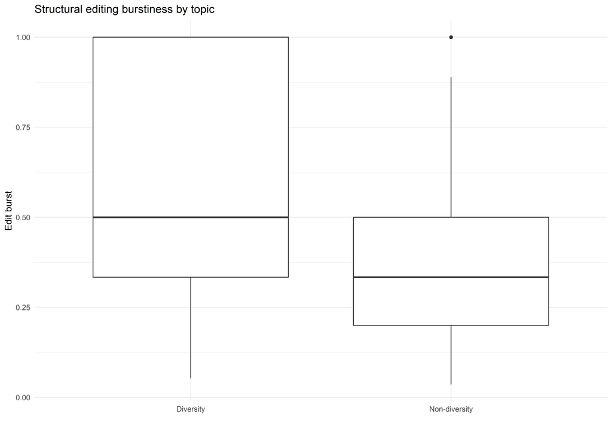

Structural editing burstiness by topic

```r
p_page_burst <- page_instability %>%
  mutate(topic_label = if_else(diversity_topic, "Diversity", "Non-diversity")) %>%
  ggplot(aes(x = topic_label, y = edit_burst)) +
  geom_boxplot() +
  labs(
    title = "Structural editing burstiness by topic",
    x = "",
    y = "Edit burst"
  ) +
  theme_minimal()

save_plot_png(p_page_burst, "structural_edit_burst_by_topic.png")

p_page_burst
```

```r
test_h1_all <- t.test(mean_reverted_share_day ~ diversity_topic, data = page_instability)
test_h2_all <- t.test(edit_burst ~ diversity_topic, data = page_instability)

test_h1_all
```

```
    Welch Two Sample t-test

data:  mean_reverted_share_day by diversity_topic
t = 0.36383, df = 540.6, p-value = 0.7161
alternative hypothesis: true difference in means between group FALSE and group TRUE is not equal to 0
95 percent confidence interval:
 -0.02293656  0.03336430
sample estimates:
mean in group FALSE  mean in group TRUE
          0.1789040           0.1736901
```

```r
test_h2_all
```

```
    Welch Two Sample t-test

data:  edit_burst by diversity_topic
t = -8.4064, df = 552.99, p-value = 3.6e-16
alternative hypothesis: true difference in means between group FALSE and group TRUE is not equal to 0
95 percent confidence interval:
 -0.1728991 -0.1074028
sample estimates:
mean in group FALSE  mean in group TRUE
          0.4398927           0.5800437
```

### 4.1 Interpretation

At the page level, diversity-related pages do not show higher revert-related instability. Thus, H1 is not supported.

However, diversity-related pages show substantially higher edit burst than non-diversity pages. This means that editing activity on these pages is more concentrated in a small number of days. Therefore, H2 is strongly supported.

This finding suggests that topic-related instability exists, but it is expressed less through reverts and more through temporal concentration of editing activity.

## 5 Temporal Instability at the Day Level

We next examine instability at the page-day level. Here, the goal is to identify whether certain days are unusually intense relative to a page’s typical editing pattern.

```r
#| label: 06_day_results_table
#| tbl-cap: "Day-level instability by topic group"

result_days_all <- daily_analysis %>%
  group_by(diversity_topic) %>%
  summarise(
    n_page_days = n(),
    n_pages = n_distinct(page_id),
    mean_edits_day = mean(edits_day, na.rm = TRUE),
    median_edits_day = median(edits_day, na.rm = TRUE),
    mean_editors_day = mean(editors_day, na.rm = TRUE),
    mean_reverted_share_day = mean(reverted_share_day, na.rm = TRUE),
    burst_day_rate = mean(burst_day, na.rm = TRUE),
    burst_day_rate_sd = mean(burst_day_sd, na.rm = TRUE),
    .groups = "drop"
  )
save_table_csv(result_days_all, "result_days_all.csv")
result_days_all |>
  kable(digits = 3, caption = "Day-level instability by topic group") |>
  kable_styling(full_width = FALSE)
```

Day-level instability by topic group

| diversity_topic | n_page_days | n_pages | mean_edits_day | median_edits_day | mean_editors_day | mean_reverted_share_day | burst_day_rate | burst_day_rate_sd |
| --- | --- | --- | --- | --- | --- | --- | --- | --- |
| FALSE | 15595 | 3078 | 1.157 | 1 | 1.110 | 0.172 | 0.031 | 0.036 |
| TRUE | 1393 | 441 | 1.081 | 1 | 1.042 | 0.183 | 0.019 | 0.019 |

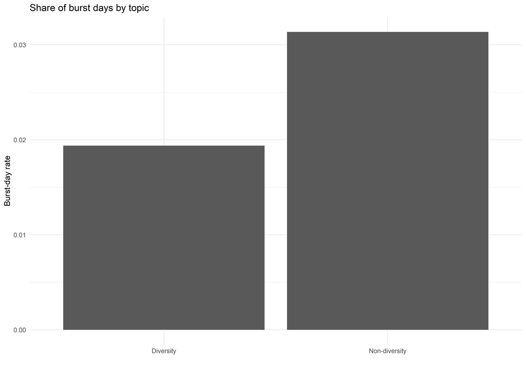

Share of burst days by topic

```r
p_burst_day <- daily_analysis %>%
  group_by(diversity_topic) %>%
  summarise(
    burst_day_rate = mean(burst_day, na.rm = TRUE),
    .groups = "drop"
  ) %>%
  mutate(topic_label = if_else(diversity_topic, "Diversity", "Non-diversity")) %>%
  ggplot(aes(x = topic_label, y = burst_day_rate)) +
  geom_col() +
  labs(
    title = "Share of burst days by topic",
    x = "",
    y = "Burst-day rate"
  ) +
  theme_minimal()

save_plot_png(p_burst_day, "burst_day_rate_by_topic.png")

p_burst_day
```

```r
test_h3_all <- t.test(as.numeric(burst_day) ~ diversity_topic, data = daily_analysis)
test_h3_all
```

```
    Welch Two Sample t-test

data:  as.numeric(burst_day) by diversity_topic
t = 3.0313, df = 1814.2, p-value = 0.002469
alternative hypothesis: true difference in means between group FALSE and group TRUE is not equal to 0
95 percent confidence interval:
 0.004226638 0.019720515
sample estimates:
mean in group FALSE  mean in group TRUE
         0.03135620          0.01938263
```

### 5.1 Interpretation

At the day level, the results do not support H3. In fact, burst days are not more common among diversity-related pages under the present operationalization.

This does not contradict the page-level finding of higher edit burst. Rather, it suggests that the instability of diversity-related pages is not driven by a higher frequency of burst days, but by stronger concentration of edits into relatively few days.

In other words, diversity-related pages appear more structurally bursty even though they do not experience burst days more often.

## 6 Mitigation Strategies

We evaluate several mitigation strategies to assess whether data reliability can be improved once instability has been detected.

- revert-based filtering
- revert-based weighting
- topic/burst-based weighting
- event-day trimming
- combined mitigation

```r
revert_threshold <- quantile(page_instability$mean_reverted_share_day, 0.95, na.rm = TRUE)

page_revert_filtered <- page_instability %>%
  filter(mean_reverted_share_day <= revert_threshold)

page_revert_weighted <- page_instability %>%
  mutate(weight_revert = 1 / (1 + mean_reverted_share_day))

page_burst_weighted <- page_instability %>%
  mutate(weight_burst = 1 / (1 + edit_burst))

daily_trimmed <- daily_analysis %>%
  filter(!burst_day)

daily_trimmed_page <- daily_trimmed %>%
  group_by(page_id, page_title, diversity_topic, biography_topic) %>%
  summarise(
    n_active_days = n(),
    n_edits = sum(edits_day, na.rm = TRUE),
    mean_reverted_share_day = mean(reverted_share_day, na.rm = TRUE),
    edit_burst = max(edits_day, na.rm = TRUE) / sum(edits_day, na.rm = TRUE),
    .groups = "drop"
  ) %>%
  mutate(weight_combined = 1 / (1 + edit_burst))
```

```r
mitigation_compare <- bind_rows(
  page_instability %>%
    group_by(diversity_topic) %>%
    summarise(
      design = "raw",
      mean_reverted_share_day = mean(mean_reverted_share_day, na.rm = TRUE),
      mean_edit_burst = mean(edit_burst, na.rm = TRUE),
      mean_n_edits = mean(n_edits, na.rm = TRUE),
      .groups = "drop"
    ),
  page_revert_filtered %>%
    group_by(diversity_topic) %>%
    summarise(
      design = "revert_filtered",
      mean_reverted_share_day = mean(mean_reverted_share_day, na.rm = TRUE),
      mean_edit_burst = mean(edit_burst, na.rm = TRUE),
      mean_n_edits = mean(n_edits, na.rm = TRUE),
      .groups = "drop"
    ),
  page_revert_weighted %>%
    group_by(diversity_topic) %>%
    summarise(
      design = "revert_weighted",
      mean_reverted_share_day = weighted.mean(mean_reverted_share_day, weight_revert, na.rm = TRUE),
      mean_edit_burst = weighted.mean(edit_burst, weight_revert, na.rm = TRUE),
      mean_n_edits = weighted.mean(n_edits, weight_revert, na.rm = TRUE),
      .groups = "drop"
    ),
  page_burst_weighted %>%
    group_by(diversity_topic) %>%
    summarise(
      design = "topic_burst_weighted",
      mean_reverted_share_day = weighted.mean(mean_reverted_share_day, weight_burst, na.rm = TRUE),
      mean_edit_burst = weighted.mean(edit_burst, weight_burst, na.rm = TRUE),
      mean_n_edits = weighted.mean(n_edits, weight_burst, na.rm = TRUE),
      .groups = "drop"
    ),
  daily_trimmed %>%
    group_by(diversity_topic) %>%
    summarise(
      design = "event_day_trimmed",
      mean_reverted_share_day = mean(reverted_share_day, na.rm = TRUE),
      mean_edit_burst = mean(burst_intensity, na.rm = TRUE),
      mean_n_edits = mean(edits_day, na.rm = TRUE),
      .groups = "drop"
    ),
  daily_trimmed_page %>%
    group_by(diversity_topic) %>%
    summarise(
      design = "combined",
      mean_reverted_share_day = weighted.mean(mean_reverted_share_day, weight_combined, na.rm = TRUE),
      mean_edit_burst = weighted.mean(edit_burst, weight_combined, na.rm = TRUE),
      mean_n_edits = weighted.mean(n_edits, weight_combined, na.rm = TRUE),
      .groups = "drop"
    )
)

save_table_csv(mitigation_compare, "mitigation_compare.csv")

mitigation_compare |>
  kable(digits = 3, caption = "Mitigation comparison across designs") |>
  kable_styling(full_width = FALSE)
```

Mitigation comparison across designs

| diversity_topic | design | mean_reverted_share_day | mean_edit_burst | mean_n_edits |
| --- | --- | --- | --- | --- |
| FALSE | raw | 0.179 | 0.440 | 5.860 |
| TRUE | raw | 0.174 | 0.580 | 3.415 |
| FALSE | revert_filtered | 0.142 | 0.424 | 6.047 |
| TRUE | revert_filtered | 0.114 | 0.556 | 3.560 |
| FALSE | revert_weighted | 0.138 | 0.448 | 5.827 |
| TRUE | revert_weighted | 0.123 | 0.590 | 3.350 |
| FALSE | topic_burst_weighted | 0.181 | 0.384 | 6.641 |
| TRUE | topic_burst_weighted | 0.177 | 0.513 | 3.965 |
| FALSE | event_day_trimmed | 0.172 | 0.197 | 1.086 |
| TRUE | event_day_trimmed | 0.184 | 0.318 | 1.051 |
| FALSE | combined | 0.181 | 0.370 | 6.101 |
| TRUE | combined | 0.178 | 0.504 | 3.796 |

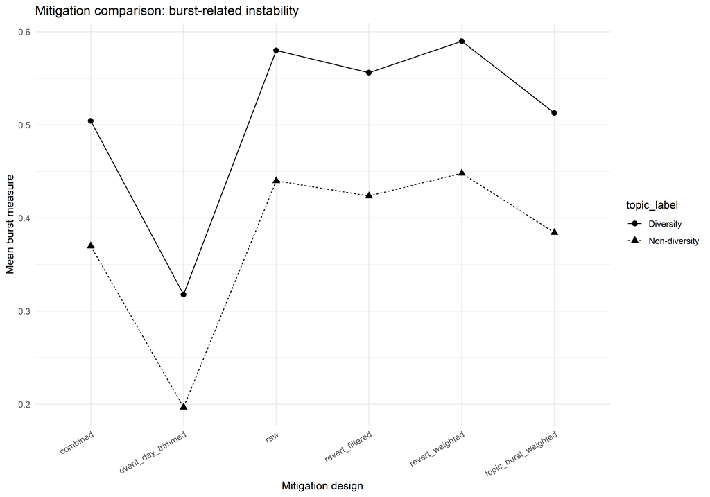

Mitigation comparison: burst-related instability

```r
p_mit_burst <- mitigation_compare %>%
  mutate(topic_label = if_else(diversity_topic, "Diversity", "Non-diversity")) %>%
  ggplot(aes(x = design, y = mean_edit_burst, group = topic_label)) +
  geom_line(aes(linetype = topic_label)) +
  geom_point(aes(shape = topic_label), size = 2.5) +
  labs(
    title = "Mitigation comparison: burst-related instability",
    x = "Mitigation design",
    y = "Mean burst measure"
  ) +
  theme_minimal() +
  theme(axis.text.x = element_text(angle = 30, hjust = 1))

save_plot_png(p_mit_burst, "mitigation_burst.png")

p_mit_burst
```

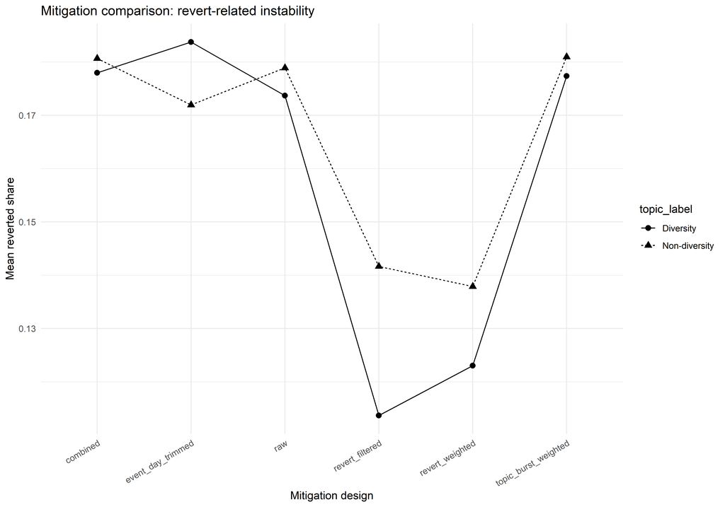

Mitigation comparison: revert-related instability

```r
p_mit_revert <- mitigation_compare %>%
  mutate(topic_label = if_else(diversity_topic, "Diversity", "Non-diversity")) %>%
  ggplot(aes(x = design, y = mean_reverted_share_day, group = topic_label)) +
  geom_line(aes(linetype = topic_label)) +
  geom_point(aes(shape = topic_label), size = 2.5) +
  labs(
    title = "Mitigation comparison: revert-related instability",
    x = "Mitigation design",
    y = "Mean reverted share"
  ) +
  theme_minimal() +
  theme(axis.text.x = element_text(angle = 30, hjust = 1))

save_plot_png(p_mit_revert, "mitigation_revert.png")

p_mit_revert
```

## 7 Results

This section reports the empirical results of the comparison between diversity-related and non-diversity Wikipedia pages across three dimensions of instability: revert activity, structural burstiness, and burst-day frequency.

First, we examine revert-related instability (H1). A Welch two-sample t-test shows no statistically significant difference in the mean share of reverted edits between diversity-related and non-diversity pages ($t = 0.36$, $df = 540.6$, $p = .716$). The mean reverted share is 0.179 for non-diversity pages and 0.174 for diversity-related pages, and the 95% confidence interval includes zero. This indicates that there is no evidence of a difference in revert-based instability between the two groups.

Second, we analyse structural editing burstiness at the page level (H2). The results show a statistically significant difference between the two groups ($t = -8.41$, $df = 552.99$, $p < .001$). Diversity-related pages exhibit a higher mean level of burstiness (0.580) compared to non-diversity pages (0.440). The confidence interval does not include zero, indicating a robust difference. This indicates that editing activity on diversity-related pages is more temporally concentrated.

Third, we examine the share of burst days (H3), defined as the proportion of days classified as burst events. The difference between the two groups is statistically significant ($t = 3.03$, $df = 1814.2$, $p = .002$). However, the direction of the effect runs counter to expectations: non-diversity pages show a higher mean share of burst days (0.031) compared to diversity-related pages (0.019). This indicates that diversity-related pages do not experience burst events more frequently.

Taken together, the results reveal a differentiated pattern of instability. While diversity-related pages are not more prone to revert activity and do not exhibit a higher frequency of burst days, they show significantly higher structural burstiness. This indicates that instability in these pages is characterised by stronger temporal concentration of editing activity rather than by more frequent conflict or more frequent burst events.

Finally, we compare mitigation strategies across different measurement designs. Revert-based filtering and weighting reduce revert-related instability but have limited impact on structural burstiness. In contrast, topic- and burst-based weighting more directly reduces page-level burstiness. Event-day trimming reduces spike-related instability at the temporal level. A combined mitigation strategy affects both structural and temporal instability, but differences between diversity-related and non-diversity pages remain visible across all designs.

### 7.1 Interpretation

The mitigation results show that different strategies address different types of instability.

Revert-based filtering and weighting reduce revert-related instability, but they do not substantially reduce structural burstiness.

Topic/burst-based weighting reduces page-level burstiness more directly, indicating that it is better suited to address topic-related structural noise.

Event-day trimming reduces day-level spike-related instability, indicating that temporal instability is partially manageable through time-based filtering.

The combined strategy addresses both structural and temporal instability, but the gap between diversity-related and non-diversity pages does not disappear completely. This suggests that some instability is not simply noise to be removed, but a structural feature of how these pages are edited.

## 8 Discussion

This study examined whether diversity-related Wikipedia pages are more unstable than other pages, and whether that instability can be understood as a data quality issue.

The results provide mixed evidence.

First, we do not find evidence that diversity-related pages are more revert-prone. H1 is therefore not supported. This means that instability in these pages is not primarily a matter of overt revert conflict.

Second, diversity-related pages are significantly more bursty at the page level. H2 is strongly supported. This indicates that editing activity is more temporally concentrated for these pages, suggesting a form of structural topic-related instability.

Third, the day-level analysis does not support H3. Diversity-related pages are not more likely to experience burst days under the present definition. This means that higher instability does not arise because these pages encounter more burst events. Instead, the key issue appears to be that a relatively small number of days account for a larger share of editing activity.

Taken together, these findings suggest that instability in Wikipedia has at least two dimensions:

topic-related structural instability, reflected in higher page-level edit burst; and event-related temporal instability, reflected in burst days and editing spikes.

These dimensions are related but not identical. Diversity-related pages appear especially prone to the first.

From a data quality perspective, this matters because instability is not captured adequately by revert rate alone. A page may not be highly revert-prone but still be unstable if its content is disproportionately shaped by a few concentrated editing periods.

The mitigation analysis reinforces this interpretation. Revert-based mitigation helps with revert-related noise, but not with burst-related instability. Topic/burst-based weighting and event-day trimming each address different aspects of the problem. A combined strategy is therefore preferable when the goal is to improve data reliability without simply excluding controversial topics altogether.